# Documentation of Shiny application

Yasukazu IKAMI

Saturday, June 13, 2015

# Summary

This shiny application calculates and illustrates the combined distribution of two sets of random sampling from normal distribution.

# Description

Two sample sets named `input1` and `input2`, with size `nsamp` are prepared. Parameter of `input1` and `input2` are their means and standard deviations. For `input1` mean is `mu1`, standard deviation is `sd1`. Same rule for `input2`.

Each elements from two sample sets are averaged. And new sample set `average` is generated. Shiny application illustrates the relation of input and averaged distributions graphically. User can input mean and standard deviation parameter for each of input distributions and number of samples.

Range of parameters are as follows. `nsamp` 2 to 1000000, default = 100. `mu1` -10 to 10, default = 0. `sd1` 1 to 10, default = 1. `mu2` -10 to 10, default = 0. `sd2` 1 to 10, default = 1.

Here is a example. Where number of sample `nsamp` is 10000. Parameter of `input1` is `mu1 = 0, sd1 = 1` and for `input2`, they are `mu2 = 10, and sd2 = 2`. Histogram of sample sets are illustrated.

```
## Using  as id variables
```

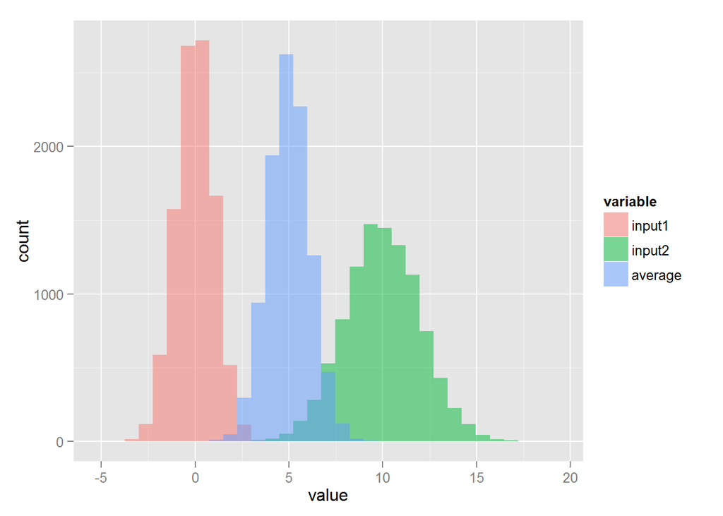

And server.R calculates the mean and standard deviation of averaged sample set.

```r
mu3
```

```
## [1] 4.998532
```

```r
sd3
```

```
## [1] 1.116053
```